# Assignment 5

In this assignment, you'll scrape text from [The California Aggie](https://theaggie.org/) and then analyze the text.

The Aggie is organized by category into article lists. For example, there's a [Campus News](https://theaggie.org/campus/) list, [Arts & Culture](https://theaggie.org/arts/) list, and [Sports](https://theaggie.org/sports/) list. Notice that each list has multiple pages, with a maximum of 15 articles per page.

The goal of exercises 1.1 - 1.3 is to scrape articles from the Aggie for analysis in exercise 1.4.

**Exercise 1.1.** Write a function that extracts all of the links to articles in an Aggie article list. The function should:

- Have a parameter `url` for the URL of the article list.
- Have a parameter `page` for the number of pages to fetch links from. The default should be `1`.
- Return a list of aricle URLs (each URL should be a string).

Test your function on 2-3 different categories to make sure it works.

Hints:

- Be polite to The Aggie and save time by setting up [requests_cache](https://pypi.python.org/pypi/requests-cache) before you write your function.
- Start by getting your function to work for just 1 page. Once that works, have your function call itself to get additional pages.
- You can use [lxml.html](http://lxml.de/lxmlhtml.html) or [BeautifulSoup](https://www.crummy.com/software/BeautifulSoup/bs4/doc/) to scrape HTML. Choose one and use it throughout the entire assignment.

```python
import requests
import requests_cache
import pandas as pd
import numpy as np
import lxml.html as lx
from matplotlib import pyplot as plt
plt.style.use('ggplot')
%matplotlib inline
import nltk
from sklearn.feature_extraction.text import TfidfVectorizer
from sklearn.neighbors import NearestNeighbors
from nltk import corpus
from nltk.stem.porter import PorterStemmer
from nltk.corpus import stopwords
from collections import Counter
from wordcloud import WordCloud
```

```python
requests_cache.install_cache('cache')
```

The different extensions to the url's are /campus/, /arts/ & /sports/

```python
def fetch(ext, num=None):
    baseurl = 'https://theaggie.org/'
    links = []
    if num is None: # sets default num pages to be 1
        num = 1
    for i in range(1,num+1):
        url = baseurl+ext+'/'+'page/'+str(i)+'/' # let function adapt to more pages requested
        req = requests.get(url)
        req.raise_for_status
        html = lx.fromstring(req.text)
        link = html.xpath('//article/p/a/@href')
        links.extend(link)
    return links
fetch('campus',1)
```

```
['https://theaggie.org/2017/02/24/2017-winter-quarter-election-results/',
 'https://theaggie.org/2017/02/23/university-of-california-davis-city-council-sever-wells-fargo-contracts/',
 'https://theaggie.org/2017/02/23/academics-unite-in-peaceful-rally-against-immigration-ban/',
 'https://theaggie.org/2017/02/23/memorial-union-to-reopen-spring-quarter/',
 'https://theaggie.org/2017/02/23/asucd-president-alex-lee-vetoes-amendment-for-creation-of-judicial-council/',
 'https://theaggie.org/2017/02/22/senate-candidate-zaki-shaheen-withdraws-from-race/',
 'https://theaggie.org/2017/02/21/uc-davis-experiences-several-recent-hate-based-crimes/',
 'https://theaggie.org/2017/02/21/uc-president-selects-gary-may-as-new-uc-davis-chancellor/',
 'https://theaggie.org/2017/02/20/katehi-controversy-prompts-decline-of-uc-administrators-seeking-profitable-subsidiary-board-positions/',
 'https://theaggie.org/2017/02/20/asucd-senate-passes-resolution-submitting-comments-on-lrdp/',
 'https://theaggie.org/2017/02/20/uc-releases-2016-annual-report-on-sustainable-practices/',
 'https://theaggie.org/2017/02/19/uc-davis-global-affairs-holds-discussion-on-president-donald-trumps-executive-orders-on-immigration/',
 'https://theaggie.org/2017/02/19/trumps-immigration-ban-affects-uc-davis-community/',
 'https://theaggie.org/2017/02/17/uc-davis-students-participate-in-uc-wide-nodapl-day-of-action/',
 'https://theaggie.org/2017/02/17/uc-davis-holds-first-mental-health-conference/']
```

```python
testurl = 'https://theaggie.org/2017/02/14/project-toto-aims-to-address-questions-regarding-city-finances/'
```

**Exercise 1.2.** Write a function that extracts the title, text, and author of an Aggie article. The function should:

- Have a parameter `url` for the URL of the article.
- For the author, extract the "Written By" line that appears at the end of most articles. You don't have to extract the author's name from this line.
- Return a dictionary with keys "url", "title", "text", and "author". The values for these should be the article url, title, text, and author, respectively.

For example, for [this article](https://theaggie.org/2017/02/14/project-toto-aims-to-address-questions-regarding-city-finances/) your function should return something similar to this:

```
{
    'author': u'Written By: Bianca Antunez \xa0\u2014\xa0city@theaggie.org',
    'text': u'Davis residents create financial model to make city\'s financial state more transparent To increase transparency between the city\'s financial situation and the community, three residents created a model called Project Toto which aims to improve how the city communicates its finances in an easily accessible design. Jeff Miller and Matt Williams, who are members of Davis\' Finance and Budget Commission, joined together with Davis entrepreneur Bob Fung to create the model plan to bring the project to the Finance and Budget Commission in February, according to Kelly Stachowicz, assistant city manager. "City staff appreciate the efforts that have gone into this, and the interest in trying to look at the city\'s potential financial position over the long term," Stachowicz said in an email interview. "We all have a shared goal to plan for a sound fiscal future with few surprises. We believe the Project Toto effort will mesh well with our other efforts as we build the budget for the next fiscal year and beyond." Project Toto complements the city\'s effort to amplify the transparency of city decisions to community members. The aim is to increase the understanding about the city\'s financial situation and make the information more accessible and easier to understand. The project is mostly a tool for public education, but can also make predictions about potential decisions regarding the city\'s financial future. Once completed, the program will allow residents to manipulate variables to see their eventual consequences, such as tax increases or extensions and proposed developments "This really isn\'t a budget, it is a forecast to see the intervention of these decisions," Williams said in an interview with The Davis Enterprise. "What happens if we extend the sales tax? What does it do given the other numbers that are in?" Project Toto enables users, whether it be a curious Davis resident, a concerned community member or a city leader, with the ability to project city finances with differing variables. The online program consists of the 400-page city budget for the 2016-2017 fiscal year, the previous budget, staff reports and consultant analyses. All of the documents are cited and accessible to the public within Project Toto. "It\'s a model that very easily lends itself to visual representation," Mayor Robb Davis said. "You can see the impacts of decisions the council makes on the fiscal health of the city." Complementary to this program, there is also a more advanced version of the model with more in-depth analyses of the city\'s finances. However, for an easy-to-understand, simplistic overview, Project Toto should be enough to help residents comprehend Davis finances. There is still more to do on the project, but its creators are hard at work trying to finalize it before the 2017-2018 fiscal year budget. "It\'s something I have been very much supportive of," Davis said. "Transparency is not just something that I have been supportive of but something we have stated as a city council objective [ ] this fits very well with our attempt to inform the public of our challenges with our fiscal situation." ',
    'title': 'Project Toto aims to address questions regarding city finances',
    'url': 'https://theaggie.org/2017/02/14/project-toto-aims-to-address-questions-regarding-city-finances/'
}
```

Hints:

- The author line is always the last line of the last paragraph.
- Python 2 displays some Unicode characters as `\uXXXX`. For instance, `\u201c` is a left-facing quotation mark. You can convert most of these to ASCII characters with the method call (on a string)

  ```
  .translate({ 0x2018:0x27, 0x2019:0x27, 0x201C:0x22, 0x201D:0x22, 0x2026:0x20 })
  ```

  If you're curious about these characters, you can look them up on [this page](http://unicode.org/cldr/utility/character.jsp), or read more about [what Unicode is](http://unicode.org/standard/WhatIsUnicode.html).

```python
def parse(url):
    req = requests.get(url) #standard get request of webpage
    req.raise_for_status #status flag
    html = lx.fromstring(req.text) # convert to html
    title = html.xpath('//article/header')[0].text_content() # find title in header tag of article
    title = title.replace('\n','').replace('\t','') # clean up title slightly
    author = html.xpath('//article//div/p')[-1].text_content() #last p tag contains author
    author = author.split('\n')[-1] # this takes the last line of the last p tag which is the author
    text = html.xpath('//article//div/p')[0:-1] # extract all but paragraph containing author
    text_list = [x.text_content().strip() for x in text]
    text_list = '\n'.join(text_list) # join together to be one string/unicode
    if type(text_list) is unicode:
        text_list = text_list.translate({ 0x2018:0x27, 0x2019:0x27, 0x201C:0x22, 0x201D:0x22, 0x2026:0x20 })
    text_list = text_list.replace('\n',' ')
    mydict = {'author':author, 'text':text_list, 'url':testurl, 'title':title}
    return mydict
parse(testurl) # demonstrate
```

```
{'author': u'Written By: Bianca Antunez \xa0\u2014\xa0city@theaggie.org',
 'text': u'Davis residents create financial model to make city\'s financial state more transparent To increase transparency between the city\'s financial situation and the community, three residents created a model called Project Toto which aims to improve how the city communicates its finances in a…
 'title': '                        Project Toto aims to address questions regarding city finances                                                                    ',
 'url': 'https://theaggie.org/2017/02/14/project-toto-aims-to-address-questions-regarding-city-finances/'}
```

**Exercise 1.3.** Use your functions from exercises 1.1 and 1.2 to get a data frame of 60 [Campus News](https://theaggie.org/campus/) articles and a data frame of 60 [City News](https://theaggie.org/city/) articles. Add a column to each that indicates the category, then combine them into one big data frame.

The "text" column of this data frame will be your corpus for natural language processing in exercise 1.4.

```python
# There are 15 articles per page so to get 60 articles we extract 4 pages worth
camplist = fetch('campus',4)
citylist = fetch('city',4)
```

```python
campus = [parse(x) for x in camplist]
city = [parse(x) for x in citylist]
```

```python
campus = pd.DataFrame(campus)
city = pd.DataFrame(city)
```

```python
campus['category'] = 'Campus' # add category column
```

```python
city['category'] = 'City'
```

```python
frames = [campus, city]
df = pd.concat(frames) # concatenate to one final dataframe, 120 rows long
df = df.reset_index() #reset index as it had two of each index
del df['index'] # delete column previous command created
```

```python
df # this is our final dataframe to work with
```

|  | author | text | title | url | category |
| --- | --- | --- | --- | --- | --- |
| 0 | Written by: Alyssa Vandenberg — campus@theagg... | Six senators, new executive team elected Curre... | 2017 Winter Quarter el... | https://theaggie.org/2017/02/14/project-toto-a... | Campus |
| 1 | Written by: Aaron Liss and Raul Castellanos —... | Wells Fargo faces fraud, predatory lending cha... | University of Californ... | https://theaggie.org/2017/02/14/project-toto-a... | Campus |
| 2 | Written by: Kimia Akbari — campus@theaggie.org | Faculty, students recount personal tales of im... | Academics unite in pea... | https://theaggie.org/2017/02/14/project-toto-a... | Campus |
| 3 | Written by: Kenton Goldsby — campus@theaggie.org | Opening date pushed back to May 1 Students hav... | Memorial Union to reop... | https://theaggie.org/2017/02/14/project-toto-a... | Campus |
| 4 | Written by: Ivan Valenzuela — campus@theaggie.org | Veto included revision abandoning creation of ... | ASUCD President Alex L... | https://theaggie.org/2017/02/14/project-toto-a... | Campus |
| 5 | Written by: Alyssa Vandenberg — campus@theagg... | Shaheen's name to remain on ballot, his votes ... | Senate candidate Zaki ... | https://theaggie.org/2017/02/14/project-toto-a... | Campus |
| 6 | Written by: Aaron Liss — campus@theaggie.org | Students receive email warnings from UC Davis ... | UC Davis experiences s... | https://theaggie.org/2017/02/14/project-toto-a... | Campus |
| 7 | Written by: Alyssa Vandenberg — campus@theagg... | UC Board of Regents to vote on the appointment... | UC President selects G... | https://theaggie.org/2017/02/14/project-toto-a... | Campus |
| 8 | Written by: Jeanna Totah — campus@theaggie.org | Tighter policies require greater approval of o... | Katehi controversy pro... | https://theaggie.org/2017/02/14/project-toto-a... | Campus |
| 9 | Written by: Ivan Valenzuela — campus@theaggie... | SR #7 asks university to increase capacity for... | ASUCD Senate passes re... | https://theaggie.org/2017/02/14/project-toto-a... | Campus |
| 10 | Written by: Yvonne Leong — campus@theaggie.org | UC Davis leads in sustainability with largest ... | UC releases 2016 Annua... | https://theaggie.org/2017/02/14/project-toto-a... | Campus |
| 11 | Written by: Kenton Goldsby — campus@theaggie.org | Speakers, including Interim Chancellor Ralph J... | UC Davis Global Affair... | https://theaggie.org/2017/02/14/project-toto-a... | Campus |
| 12 | Written by: Kimia Akbari — campus@theaggie.org | Executive order has immediate consequences for... | Trump’s immigration ba... | https://theaggie.org/2017/02/14/project-toto-a... | Campus |
| 13 | Written by: Kaitlyn Cheung — campus@theaggie.org | Student protesters march from MU flagpole to M... | UC Davis students part... | https://theaggie.org/2017/02/14/project-toto-a... | Campus |
| 14 | Written by: Jayashri Padmanabhan — campus@thea... | Conference entails full day of speakers, panel... | UC Davis holds first m... | https://theaggie.org/2017/02/14/project-toto-a... | Campus |
| 15 | Written by: Demi Caceres — campus@theaggie.org | Last week in Senate The ASUCD Senate meeting w... | Last week in Senate ... | https://theaggie.org/2017/02/14/project-toto-a... | Campus |
| 16 | Written by: Alyssa Vandenberg and Emilie DeFaz... | Executive: Josh Dalavai and Adilla Jamaludin I... | 2017 ASUCD Winter Elec... | https://theaggie.org/2017/02/14/project-toto-a... | Campus |
| 17 | Written by: Ivan Valenzuela — campus@theaggie.org | New showcase provides opportunity for students... | Shields Library hosts ... | https://theaggie.org/2017/02/14/project-toto-a... | Campus |
| 18 | Written by: Demi Caceres — campus@theaggie.org | Students promote fruit and vegetable meals via... | Student Health and Cou... | https://theaggie.org/2017/02/14/project-toto-a... | Campus |
| 19 | Written by: Lindsay Floyd — campus@theaggie.org | New fees to pay for equipment replacement To c... | PE classes may charge ... | https://theaggie.org/2017/02/14/project-toto-a... | Campus |
| 20 | Written by: Jeanna Totah — campus@theaggie.org | Recipients each rewarded $25,000 for research ... | 11 new Chancellor Fell... | https://theaggie.org/2017/02/14/project-toto-a... | Campus |
| 21 | Written by: Aaron Liss — campus@theaggie.org | Muslim Student Association curates five-part D... | Muslim students respon... | https://theaggie.org/2017/02/14/project-toto-a... | Campus |
| 22 | Written by: Lindsay Floyd — campus@theaggie.or... | Events to promote safe sex On Feb. 1, Student ... | Sexcessful Campaign la... | https://theaggie.org/2017/02/14/project-toto-a... | Campus |
| 23 | Written by: Alyssa Vandenberg — campus@theagg... | Chan replaces former senator Sam Park Michael ... | Michael Chan sworn in ... | https://theaggie.org/2017/02/14/project-toto-a... | Campus |
| 24 | Written by: Kenton Goldsby — campus@theaggie.org | Regents approve tuition increase in 16-4 vote ... | University of Californ... | https://theaggie.org/2017/02/14/project-toto-a... | Campus |
| 25 | Written by: Yvonne Leong — campus@theaggie.org | Last week in Senate The ASUCD Senate meeting w... | Last week in Senate ... | https://theaggie.org/2017/02/14/project-toto-a... | Campus |
| 26 | Written by: Jayashri Padmanabhan — campus@thea... | Funding to expand innovation, entrepreneurship... | UC Davis receives $2.2... | https://theaggie.org/2017/02/14/project-toto-a... | Campus |
| 27 | Written by: Ivan Valenzuela — campus@theaggie.org | Davis College Democrats host Dodd for question... | Senator Bill Dodd visi... | https://theaggie.org/2017/02/14/project-toto-a... | Campus |
| 28 | Written by: Kenton Goldsby — campus@theaggie.org | Law to affect students selected to attend Nati... | AB 1887 prevents use o... | https://theaggie.org/2017/02/14/project-toto-a... | Campus |
| 29 | Written by: Jayashri Padmanabhan — campus@thea... | Kathleen Salvaty to oversee implementation of ... | UC system hires Title ... | https://theaggie.org/2017/02/14/project-toto-a... | Campus |
| ... | ... | ... | ... | ... | ... |
| 90 | Written by: Raul Castellanos Jr. — city@theagg... | Downtown Davis offers a wide range of Thai cui... | No such thing as too m... | https://theaggie.org/2017/02/14/project-toto-a... | City |
| 91 | Written by: Kaelyn Tuermer-Lee – city@theaggie... | Petco Foundation awards $10,000 to local anima... | A dog named Disney win... | https://theaggie.org/2017/02/14/project-toto-a... | City |
| 92 | Written by: Andie Joldersma — city@theaggie.org | Books by Mail program will deliver materials s... | Yolo County Library ma... | https://theaggie.org/2017/02/14/project-toto-a... | City |
| 93 | Written by: Sam Solomon — city@theaggie.org | Season's Greetings Edition Dec. 24 "Downstairs... | Police Logs ... | https://theaggie.org/2017/02/14/project-toto-a... | City |
| 94 | Written By: Dianna Rivera — city@theaggie.org | The Davis Manor Neighborhood hosts first Holid... | Neighbors unite ... | https://theaggie.org/2017/02/14/project-toto-a... | City |
| 95 | Written by: Kaelyn Tuermer-Lee — city@theaggie... | Local author Matt Biers-Ariel's latest novel M... | Sparks fly in Light th... | https://theaggie.org/2017/02/14/project-toto-a... | City |
| 96 | Written by: Raul Castellanos Jr. — city@theagg... | Volunteer program distributes bicycles, aims t... | Bike Campaign offers b... | https://theaggie.org/2017/02/14/project-toto-a... | City |
| 97 | Written By: Juno Bhardwaj-shah — city@theaggie... | Speakers criticize "unconstitutional" system O... | Bail reform advocates ... | https://theaggie.org/2017/02/14/project-toto-a... | City |
| 98 | Written by: Samantha Solomon – city@theaggie.org | Live-action retelling of Christmas poem promis... | ‘Twas the Night Before... | https://theaggie.org/2017/02/14/project-toto-a... | City |
| 99 | Written by: Sam Solomon — city@theaggie.org | 35th annual tree lighting ceremony kicks off w... | Children’s Candlelight... | https://theaggie.org/2017/02/14/project-toto-a... | City |
| 100 | Written by: Sam Solomon – city@theaggie.org | Another week of 'why did people call the polic... | Police Logs ... | https://theaggie.org/2017/02/14/project-toto-a... | City |
| 101 | Written By: Dianna Rivera – city@theaggie.org | The Yolo County Children's Alliance celebrates... | The season of giving ... | https://theaggie.org/2017/02/14/project-toto-a... | City |
| 102 | Written by: Samantha Solomon — city@theaggie.org | Students, activists call for solidarity with S... | NoDAPL protest erupts ... | https://theaggie.org/2017/02/14/project-toto-a... | City |
| 103 | Written by: Andie Joldersma — city@theaggie.org | Participants gathered for 5k, 10k, half marath... | Davis Turkey Trot: mor... | https://theaggie.org/2017/02/14/project-toto-a... | City |
| 104 | Written By: Andie Joldersma — city@theaggie.org | Citizens can expect more cost-competitive clea... | Affordable, clean, gre... | https://theaggie.org/2017/02/14/project-toto-a... | City |
| 105 | Written by: Bianca Antunez – city@theaggie.org | Davis community renews local parcel tax for K-... | Measure H passes, vote... | https://theaggie.org/2017/02/14/project-toto-a... | City |
| 106 | Written by: Anya Rehon — city@theaggie.org | College alcohol use, high-risk drinking discus... | Local residents attend... | https://theaggie.org/2017/02/14/project-toto-a... | City |
| 107 | Written by: Sam Solomon – city@theaggie.org | Looks like it's been an interesting week Nov. ... | Police Logs ... | https://theaggie.org/2017/02/14/project-toto-a... | City |
| 108 | Written by: Raul Castellanos Jr. — city@theagg... | Ornamental piano outside Mishka's Café vandali... | Public piano destroyed... | https://theaggie.org/2017/02/14/project-toto-a... | City |
| 109 | Written by: Samantha Solomon – city@theaggie.org | Davis residents light candles, promote sanctua... | Holding the Light ... | https://theaggie.org/2017/02/14/project-toto-a... | City |
| 110 | Written By: Dianna Rivera — city@theaggie.org | Don't be left in the dark now that Daylight Sa... | Sun down, bike lights ... | https://theaggie.org/2017/02/14/project-toto-a... | City |
| 111 | Written By: Sam Solomon — city@theaggie.org | Nov. 7 "Subject stated our pizza is ready and ... | Police Logs ... | https://theaggie.org/2017/02/14/project-toto-a... | City |
| 112 | Written by: Kaelyn Tuermer-Lee – city@theaggie... | Helping the community through Davis Community ... | Tune in to Watermelon ... | https://theaggie.org/2017/02/14/project-toto-a... | City |
| 113 | Written By: Andie Joldersma — city@theaggie.org | Protesters gather at State Capitol Building fo... | Water is sacred, water... | https://theaggie.org/2017/02/14/project-toto-a... | City |
| 114 | Written By: Anya Rehon — city@theaggie.org | The Yolo County community comes together for h... | The Yolo Food Bank add... | https://theaggie.org/2017/02/14/project-toto-a... | City |
| 115 | Written By: Bianca Antunez — city@theaggie.org | Election results are in; Davis community conce... | Nov. 8 2016: An Electi... | https://theaggie.org/2017/02/14/project-toto-a... | City |
| 116 | “Male on a motorized bike pulling a trailer, e... | More turkeys, more tomfoolery, more accidental... | Police Logs ... | https://theaggie.org/2017/02/14/project-toto-a... | City |
| 117 | Written By: Bianca Antunez – city@theaggie.org | Participants line up for Thanksgiving 5k befor... | Yolo Food Bank’s eight... | https://theaggie.org/2017/02/14/project-toto-a... | City |
| 118 | Written by: Raul Castellanos — city@theaggie.org | Bernie Sanders visits Sacramento to rally for ... | Return of the Bern ... | https://theaggie.org/2017/02/14/project-toto-a... | City |
| 119 | Written by: Alana Joldersma –– city@theaggie.org | Indoor facility will provide a cafeteria, clas... | Construction of the Al... | https://theaggie.org/2017/02/14/project-toto-a... | City |

120 rows × 5 columns

**Exercise 1.4.** Use the Aggie corpus to answer the following questions. Use plots to support your analysis.

- What topics does the Aggie cover the most? Do city articles typically cover different topics than campus articles?
- What are the titles of the top 3 pairs of most similar articles? Examine each pair of articles. What words do they have in common?
- Do you think this corpus is representative of the Aggie? Why or why not? What kinds of inference can this corpus support? Explain your reasoning.

Hints:

- The [nltk book](http://www.nltk.org/book/) and [scikit-learn documentation](http://scikit-learn.org/stable/modules/feature_extraction.html#text-feature-extraction) may be helpful here.
- You can determine whether city articles are "near" campus articles from the similarity matrix or with k-nearest neighbors.
- If you want, you can use the [wordcloud](http://amueller.github.io/word_cloud/) package to plot a word cloud. To install the package, run

  ```
  conda install -c https://conda.anaconda.org/amueller wordcloud
  ```

  in a terminal. Word clouds look nice and are easy to read, but are less precise than bar plots.

```python
stemmer = PorterStemmer().stem

tokenize = nltk.word_tokenize

def stem(tokens,stemmer = PorterStemmer().stem):
    return [stemmer(w.lower()) for w in tokens]

def lemmatize(text):
    """
    Extract simple lemmas based on tokenization and stemming
    Input: string
    Output: list of strings (lemmata)
    """
    return stem(tokenize(text))
```

```python
textd = {} #dictionary from lemmata to document ids containing that lemma
for i in range(len(df['title'])):
    t = df.loc[i,'text']
    s = set(lemmatize(t))
    try:
        toks = toks | s
    except NameError:
        toks = s
    for tok in s:
        try:
            textd[tok].append(df.loc[i,'title'])
        except KeyError:
            textd[tok] = [df.loc[i,'title']]
textd
```

[output not shown]

[output cut: 5473 more lines]

```python
docids = {} #dictionary of the document id to an integer id for the document
N = len(df['title'])
for i in xrange(N):
    docids[df.loc[i,'title']] = i
docids
```

[output not shown]

[output cut: 82 more lines]

```python
tokids = {} #dictionary of lemma to integer id for the lemma
tok_list = list(toks)
m = len(tok_list)
for j in xrange(m):
    tokids[tok_list[j]] = j
tokids
```

[output not shown]

[output cut: 946 more lines]

[output not shown]

```python
numd = {key:len(set(val)) for key,val in textd.items()}
```

```python
logN = np.log(len(df['title']))
```

```python
idf_smooth = {key:logN - np.log(1 + val) for key, val in numd.items() if val > 1}
```

```python
idf_smooth
```

[output not shown]

[output cut: 946 more lines]

[output not shown]

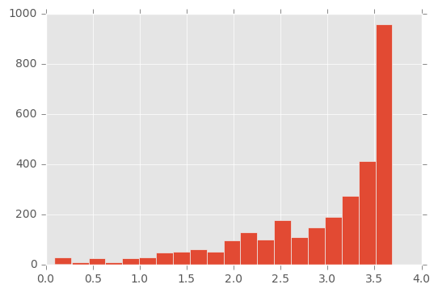

```python
plt.hist(idf_smooth.values(),bins=20)
```

```python
dict(Counter(idf_smooth).most_common(100))
```

```
{u'1,800': 3.6888794541139358,
 u'1996': 3.6888794541139358,
 u'1997': 3.6888794541139358,
 u'2,500': 3.6888794541139358,
 u'2025.': 3.6888794541139358,
 u'@': 3.6888794541139358,
 u'abov': 3.6888794541139358,
 u'accur': 3.6888794541139358,
 u'accus': 3.6888794541139358,
 u'affairs.': 3.6888794541139358,
 u'americans.': 3.6888794541139358,
 u'anastasia': 3.6888794541139358,
 u'argument': 3.6888794541139358,
 u'assault.': 3.6888794541139358,
 u'asset': 3.6888794541139358,
 u'assistance.': 3.6888794541139358,
 u'atm': 3.6888794541139358,
 u'attitud': 3.6888794541139358,
 u'available.': 3.6888794541139358,
 u'ban.': 3.6888794541139358,
 u'blanket': 3.6888794541139358,
 u'book.': 3.6888794541139358,
 u'business.': 3.6888794541139358,
 u'cancellation.': 3.6888794541139358,
 u'careers.': 3.6888794541139358,
 u'chilli': 3.6888794541139358,
 u'coho': 3.6888794541139358,
 u'compassion': 3.6888794541139358,
 u'crime.': 3.6888794541139358,
 u'detent': 3.6888794541139358,
 u'disney': 3.6888794541139358,
 u'dna': 3.6888794541139358,
 u'e.': 3.6888794541139358,
 u'easier': 3.6888794541139358,
 u'elections.': 3.6888794541139358,
 u'ever.': 3.6888794541139358,
 u'feeling.': 3.6888794541139358,
 u'fix': 3.6888794541139358,
 u'food.': 3.6888794541139358,
 u'forth': 3.6888794541139358,
```

[output cut: 45 more lines]

```
 u'student-faculti': 3.6888794541139358,
 u'tenni': 3.6888794541139358,
 u'today.': 3.6888794541139358,
 u'unitran': 3.6888794541139358,
 'updat': 3.6888794541139358,
 u'vote.': 3.6888794541139358,
 u'voter': 3.6888794541139358,
 u'warn': 3.6888794541139358,
 u'washington.': 3.6888794541139358,
 u'week.': 3.6888794541139358,
 u'wind': 3.6888794541139358,
 u'wine': 3.6888794541139358,
 u'wore': 3.6888794541139358,
 u'wors': 3.6888794541139358,
 u'wrong': 3.6888794541139358}
```

```python
# now I make two separate data frames to analyze difference between articles across sections
campusdf = df[df['category']== 'Campus']
citydf = df[df['category']=='City']
citydf = citydf.reset_index()
del citydf['index']
```

```python
# this will be for campus word frequencies
campusd = {} #dictionary from lemmata to document ids containing that lemma
for i in range(len(campusdf['title'])):
    t = campusdf.loc[i,'text']
    s = set(lemmatize(t))
    try:
        toks = toks | s
    except NameError:
        toks = s
    for tok in s:
        try:
            campusd[tok].append(campusdf.loc[i,'title'])
        except KeyError:
            campusd[tok] = [campusdf.loc[i,'title']]

campusdocids = {} #dictionary of the document id to an integer id for the document
N = len(campusdf['title'])
for i in xrange(N):
    campusdocids[campusdf.loc[i,'title']] = i

campusids = {} #dictionary of lemma to integer id for the lemma
tok_list = list(toks)
m = len(tok_list)
for j in xrange(m):
    campusids[tok_list[j]] = j

camd = {key:len(set(val)) for key,val in campusd.items()}
logCamN = np.log(len(campusdf['title']))
campus_idf_smooth = {key:logN - np.log(1 + val) for key, val in camd.items() if val > 1}

topcampus = dict(Counter(campus_idf_smooth).most_common(100))
topcampus
```

```
{u'1,800': 3.6888794541139358,
 u'1997': 3.6888794541139358,
 u'2.2': 3.6888794541139358,
 u'2015.': 3.6888794541139358,
 u'2025.': 3.6888794541139358,
 u'21': 3.6888794541139358,
 u'23': 3.6888794541139358,
 u'abandon': 3.6888794541139358,
 u'abstained.': 3.6888794541139358,
 u'accur': 3.6888794541139358,
 u'accus': 3.6888794541139358,
 u'amend': 3.6888794541139358,
 u'anastasia': 3.6888794541139358,
 u'appreci': 3.6888794541139358,
 u'attempt': 3.6888794541139358,
 u'bacon': 3.6888794541139358,
 u'beauti': 3.6888794541139358,
 u'bigger': 3.6888794541139358,
 u'breitbart': 3.6888794541139358,
 u'cancellation.': 3.6888794541139358,
 u'co-chair': 3.6888794541139358,
 u'coho': 3.6888794541139358,
 'company.': 3.6888794541139358,
 u'credit': 3.6888794541139358,
 u'dateline.': 3.6888794541139358,
 u'decision.': 3.6888794541139358,
 u'detent': 3.6888794541139358,
 u'dialogu': 3.6888794541139358,
 u'disenfranchis': 3.6888794541139358,
 u'disposal.': 3.6888794541139358,
 u'distinct': 3.6888794541139358,
 u'divid': 3.6888794541139358,
 u'down.': 3.6888794541139358,
 u'drew': 3.6888794541139358,
 u'effect.': 3.6888794541139358,
 u'elections.': 3.6888794541139358,
 u'embarrass': 3.6888794541139358,
 u'emili': 3.6888794541139358,
 u'entrepreneurship': 3.6888794541139358,
 u'failur': 3.6888794541139358,
```

[output cut: 45 more lines]

```
 u'system.': 3.6888794541139358,
 u'tackl': 3.6888794541139358,
 u'tear': 3.6888794541139358,
 u'third': 3.6888794541139358,
 u'time.': 3.6888794541139358,
 u'told': 3.6888794541139358,
 u'transit': 3.6888794541139358,
 u'treatment.': 3.6888794541139358,
 u'util': 3.6888794541139358,
 u'vandal': 3.6888794541139358,
 u'vote.': 3.6888794541139358,
 u'warm': 3.6888794541139358,
 u'whatev': 3.6888794541139358,
 u'world.': 3.6888794541139358,
 u'wors': 3.6888794541139358}
```

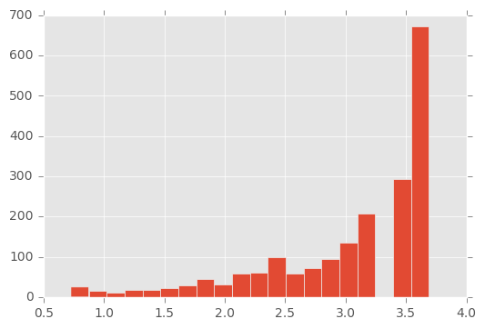

```python
plt.hist(campus_idf_smooth.values(),bins=20)
```

```python
# this will be for campus word frequencies
cityd = {} #dictionary from lemmata to document ids containing that lemma
for i in range(len(citydf['title'])):
    t = citydf.loc[i,'text']
    s = set(lemmatize(t))
    try:
        toks = toks | s
    except NameError:
        toks = s
    for tok in s:
        try:
            cityd[tok].append(citydf.loc[i,'title'])
        except KeyError:
            cityd[tok] = [citydf.loc[i,'title']]

citydocids = {} #dictionary of the document id to an integer id for the document
N = len(citydf['title'])
for i in xrange(N):
    citydocids[citydf.loc[i,'title']] = i

cityids = {} #dictionary of lemma to integer id for the lemma
tok_list = list(toks)
m = len(tok_list)
for j in xrange(m):
    cityids[tok_list[j]] = j

citd = {key:len(set(val)) for key,val in cityd.items()}
logCiN = np.log(len(citydf['title']))
city_idf_smooth = {key:logN - np.log(1 + val) for key, val in camd.items() if val > 1}

topcity = dict(Counter(city_idf_smooth).most_common(100))
topcity
```

```
{u'1,800': 3.6888794541139358,
 u'1997': 3.6888794541139358,
 u'2.2': 3.6888794541139358,
 u'2015.': 3.6888794541139358,
 u'2025.': 3.6888794541139358,
 u'21': 3.6888794541139358,
 u'23': 3.6888794541139358,
 u'abandon': 3.6888794541139358,
 u'abstained.': 3.6888794541139358,
 u'accur': 3.6888794541139358,
 u'accus': 3.6888794541139358,
 u'amend': 3.6888794541139358,
 u'anastasia': 3.6888794541139358,
 u'appreci': 3.6888794541139358,
 u'attempt': 3.6888794541139358,
 u'bacon': 3.6888794541139358,
 u'beauti': 3.6888794541139358,
 u'bigger': 3.6888794541139358,
 u'breitbart': 3.6888794541139358,
 u'cancellation.': 3.6888794541139358,
 u'co-chair': 3.6888794541139358,
 u'coho': 3.6888794541139358,
 'company.': 3.6888794541139358,
 u'credit': 3.6888794541139358,
 u'dateline.': 3.6888794541139358,
 u'decision.': 3.6888794541139358,
 u'detent': 3.6888794541139358,
 u'dialogu': 3.6888794541139358,
 u'disenfranchis': 3.6888794541139358,
 u'disposal.': 3.6888794541139358,
 u'distinct': 3.6888794541139358,
 u'divid': 3.6888794541139358,
 u'down.': 3.6888794541139358,
 u'drew': 3.6888794541139358,
 u'effect.': 3.6888794541139358,
 u'elections.': 3.6888794541139358,
 u'embarrass': 3.6888794541139358,
 u'emili': 3.6888794541139358,
 u'entrepreneurship': 3.6888794541139358,
 u'failur': 3.6888794541139358,
```

[output cut: 45 more lines]

```
 u'system.': 3.6888794541139358,
 u'tackl': 3.6888794541139358,
 u'tear': 3.6888794541139358,
 u'third': 3.6888794541139358,
 u'time.': 3.6888794541139358,
 u'told': 3.6888794541139358,
 u'transit': 3.6888794541139358,
 u'treatment.': 3.6888794541139358,
 u'util': 3.6888794541139358,
 u'vandal': 3.6888794541139358,
 u'vote.': 3.6888794541139358,
 u'warm': 3.6888794541139358,
 u'whatev': 3.6888794541139358,
 u'world.': 3.6888794541139358,
 u'wors': 3.6888794541139358}
```

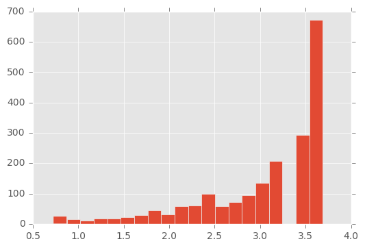

```python
plt.hist(city_idf_smooth.values(),bins=20)
```

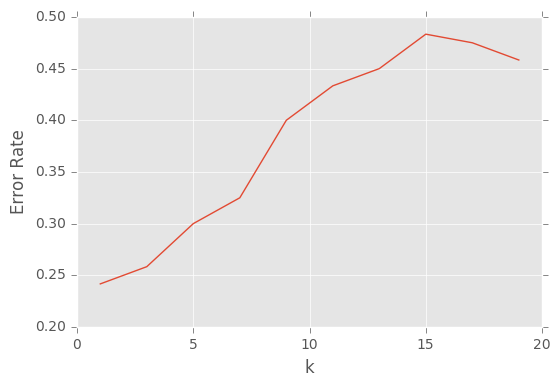

```python
vectorizer = TfidfVectorizer(tokenizer=lemmatize,stop_words="english",smooth_idf=True,norm=None)

tfs = vectorizer.fit_transform(df['text'])

label = [1]*60 + [0]*60

k_max = 20
nbrs = NearestNeighbors(n_neighbors=k_max).fit(tfs)
err_list = []

for k in xrange(1,k_max+1,2):
    neighmat = nbrs.kneighbors_graph(n_neighbors=k)
    pred_lab = (neighmat.dot(label) > k/2.)*1 #Why should this be knn classification?
    err =  np.mean(pred_lab != label)
    err_list.append(err)


plt.plot(range(1,k_max + 1,2),err_list)
plt.xlabel('k')
plt.ylabel('Error Rate')
```

We see that the lowest error rate is at k=1. This means there is no bias variance tradeoff which implies we are not predicting very well and our main concern is bias.

```python
sim = tfs.dot(tfs.T)
sim.mean()
```

```
1632.1639820308828
```

```python
sims = []
for i in range(120):
    for j in range(120):
        if i != j:
            sims.append(sim[i,j])
        else:
            sims.append(0)

simarray = np.array(sims)
```

```python
simarray.argsort()[-5:]
```

```
array([6256, 4214, 1715, 1934, 1696], dtype=int64)
```

So our pairs are [16,52], [35,14], [16,14] after some matrix algebra.

```python
print df.loc[14,"title"],df.loc[35,"title"]
```

```
                        UC Davis holds first mental health conference                                                                                             UC Davis to host first ever mental health conference
```

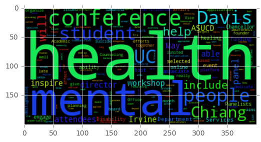

```python
wordcloud = WordCloud().generate(df.loc[35,"text"])
plt.imshow(wordcloud)
plt.show()
```

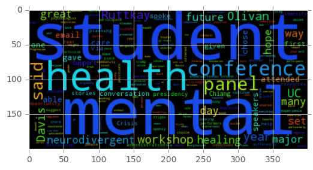

```python
wordcloud = WordCloud().generate(df.loc[14,"text"])
plt.imshow(wordcloud)
plt.show()
```

We find strong similarities amongst two articles which appear to be before and after a mental health conference. Common words are mental and health which is quite unsurprising.

```python
print df.loc[16,"title"],df.loc[52,"title"]
```

```
                        2017 ASUCD Winter Elections — Meet the Candidates                                                                                             Student organizers host “Change/The Conversation” event
```

[figure not shown]

```python
wordcloud = WordCloud().generate(df.loc[16,"text"])
plt.imshow(wordcloud)
plt.show()
```

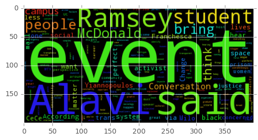

```python
wordcloud = WordCloud().generate(df.loc[52,"text"])
plt.imshow(wordcloud)
plt.show()
```

Both of these articles appear to be related to student affairs and current events within the campus they talk about students and various political jargon.

```python
print df.loc[16,"title"],df.loc[14,"title"]
```

```
                        2017 ASUCD Winter Elections — Meet the Candidates                                                                                             UC Davis holds first mental health conference
```

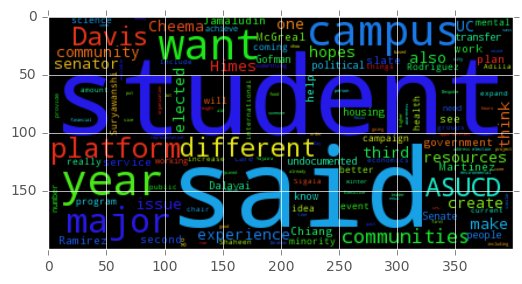

```python
wordcloud = WordCloud().generate(df.loc[16,"text"])
plt.imshow(wordcloud)
plt.show()
```

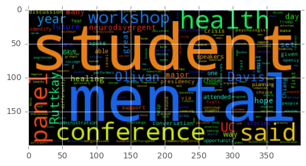

```python
wordcloud = WordCloud().generate(df.loc[14,"text"])
plt.imshow(wordcloud)
plt.show()
```

These two mainly seem to just say student a lot with Davis also being a common word. So I believe these are not necessarily so common of articles in content as they are both about activities related to students at UC Davis.

I think that this corpus may be semi-representative of the corpus but not nearly entirely representitive. We sampled from just two of their categories and two categories that are going to focus on Davis specific issues which I guess you would expect from the UC Davis newspaper but the categories we pulled from are going to inherently have a lot more articles in common than if we had also sampled from their art or sports categories. We also only took 60 articles of each and so it is a relatively current sample of the work included unter the title The Aggie. We would wonder how high their rate of turnover is among writers because it is possible that they shift a lot stylistically as student writers come and go.